# EDA - Uber Request Data

```python
import numpy as np
import pandas as pd
import matplotlib.pyplot as plt
import seaborn as sns
```

```python
df = pd.read_csv("data/Uber Data.csv")
df.head()
```

|  | Request id | Pickup point | Driver id | Status | Request timestamp | Drop timestamp |
| --- | --- | --- | --- | --- | --- | --- |
| 0 | 619 | Airport | 1.0 | Trip Completed | 11/7/2016 11:51 | 11/7/2016 13:00 |
| 1 | 867 | Airport | 1.0 | Trip Completed | 11/7/2016 17:57 | 11/7/2016 18:47 |
| 2 | 1807 | City | 1.0 | Trip Completed | 12/7/2016 9:17 | 12/7/2016 9:58 |
| 3 | 2532 | Airport | 1.0 | Trip Completed | 12/7/2016 21:08 | 12/7/2016 22:03 |
| 4 | 3112 | City | 1.0 | Trip Completed | 13-07-2016 08:33:16 | 13-07-2016 09:25:47 |

```python
df.info()
```

```
<class 'pandas.core.frame.DataFrame'>
RangeIndex: 6745 entries, 0 to 6744
Data columns (total 6 columns):
 #   Column             Non-Null Count  Dtype
---  ------             --------------  -----
 0   Request id         6745 non-null   int64
 1   Pickup point       6745 non-null   object
 2   Driver id          4095 non-null   float64
 3   Status             6745 non-null   object
 4   Request timestamp  6745 non-null   object
 5   Drop timestamp     2831 non-null   object
dtypes: float64(1), int64(1), object(4)
memory usage: 316.3+ KB
```

```python
df['Status'].value_counts()
```

```
Trip Completed       2831
No Cars Available    2650
Cancelled            1264
Name: Status, dtype: int64
```

# About the dataset

### This dataset does not contain null values, the null vlaues at the "Driver id" column is equal to the number of Status "No Cars Available" and this is normal because there is no driver for these trips, also the sum of null values at the "Drop timestamp" column is equal to the sumber of Status " No Cars Available & Cancelled" and this is normal too because these trips does not comlete too so there are no drop point ("drop timestamp").

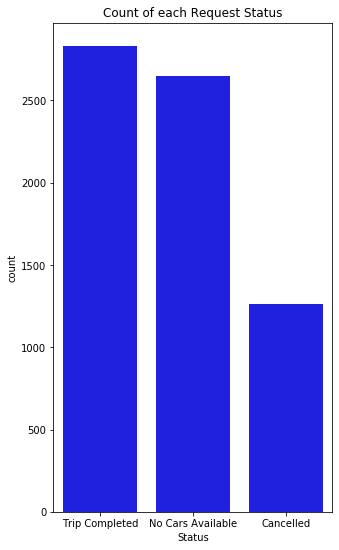

```python
#Count of each Request Status
plt.figure(figsize=(5,9))
sns.countplot(x="Status", data=df,order = df['Status'].value_counts().index, color="b")
plt.title("Count of each Request Status")
plt.show()
```

#### The above plot shows that number of requests that does not have cars available is large (2650), also there are a number of 1264 requests cancelled by the users.

#### we want use this data to extract some insights in addition to increase the number of completed trips, so we should find which times that users request cars for each pickup point in another words wich times users can not find cars to focus on raising cars service these times.

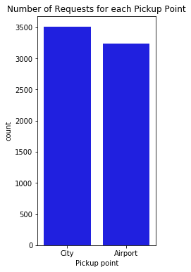

```python
#number of Requests for each trip
df['Pickup point'].value_counts()
plt.figure(figsize=(3,6))
sns.countplot(x="Pickup point", data=df,order = df['Pickup point'].value_counts().index, color="b")
plt.title("Number of Requests for each Pickup Point")
plt.show()
```

#### The count plot above show a small difference between the number of requests for the city more than the Airport, but we will go deep into this to show that the real requests which our company should target and when

```python
#conerting the dtype of the date and time column from object dtype to datetime64
df['Request timestamp'] = pd.to_datetime(df['Request timestamp'])
df['Drop timestamp'] = pd.to_datetime(df['Drop timestamp'])
```

[output not shown]

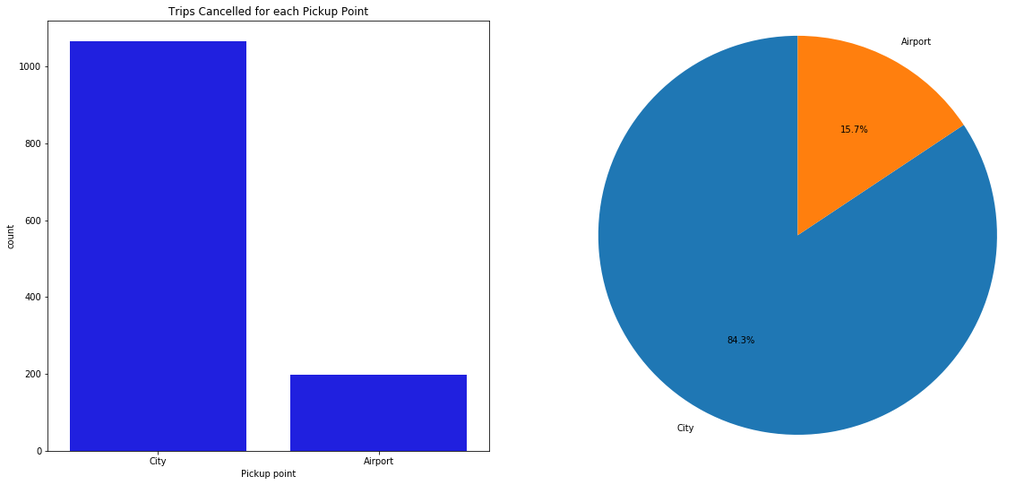

```python
df_c = df[(df["Status"] == "Cancelled")]
#plot
plt.figure(figsize=(30,30))
plt.subplot(3,3,1)
sns.countplot(x="Pickup point", data=df_c,order = df['Pickup point'].value_counts().index, color="b")
plt.title("Trips Cancelled for each Pickup Point")

plt.subplot(3,3,2)
labels = 'City', 'Airport'
sizes = df_c['Pickup point'].value_counts()
explode = (0,0)
plt.pie(sizes, explode=explode, labels=labels, autopct='%1.1f%%', startangle=90)
plt.axis('equal')
#plt.figure()
```

```python
df_c['Pickup point'].value_counts()
```

```
City       1066
Airport     198
Name: Pickup point, dtype: int64
```

#### The Count plot above show that 1066 City trip Cancelled and only 198 Airport trip Cancelled

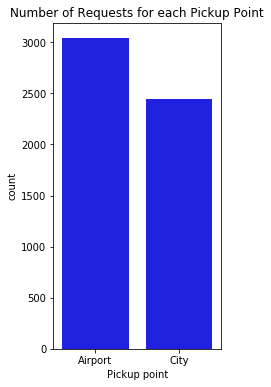

```python
#number of Requests for each trip without the Cancelled Requests
df_nc= df[df['Status'] != "Cancelled"]
plt.figure(figsize=(3,6))
sns.countplot(x="Pickup point", data=df_nc,order = df_nc['Pickup point'].value_counts().index, color="b")
plt.title("Number of Requests for each Pickup Point")
plt.show()
```

#### Now its clear here the requests from the Airport is more than the City point not the opposite we removed the Cancelled requests which would affects on our decisions.

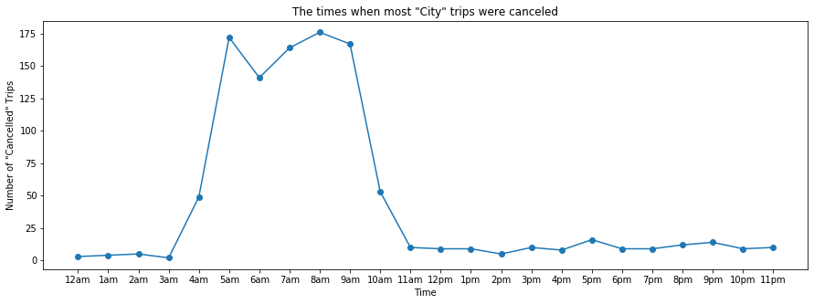

```python
# The times when most "City" trips were canceled
df_cc = df_c[(df_c["Pickup point"] == "City")]
num = []
for i in range(0,24):
    x = df_cc[df_cc['Request timestamp'].dt.hour == i]
    b = x.Status.count()
    num.append(b)
plt.figure(figsize = (15,5))
axis_time = ["12am",'1am','2am','3am','4am','5am','6am','7am','8am','9am','10am','11am','12pm','1pm','2pm','3pm','4pm','5pm','6pm','7pm','8pm','9pm','10pm','11pm']
plt.plot(axis_time,num,marker ='o')
plt.title('The times when most "City" trips were canceled')
plt.xlabel('Time')
plt.ylabel('Number of "Cancelled" Trips')
plt.show()
```

#### The Line plot above shows that the most time has Trips cancelled from 4:00 am To 10:00 am for "City" Pickup point".

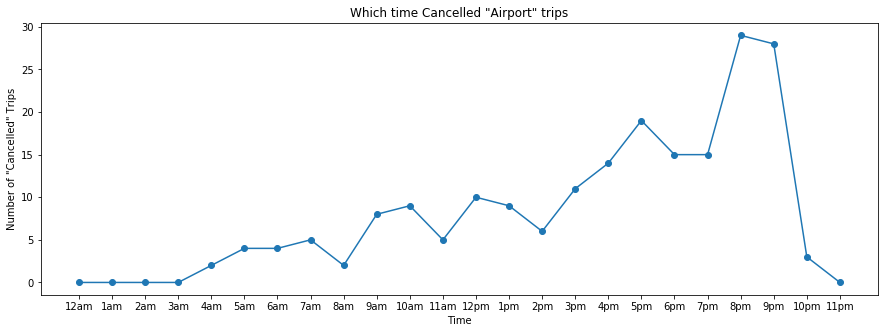

```python
# The times when most "Airport" trips were canceled
df_ac = df_c[(df_c["Pickup point"] == "Airport")]
num = []
for i in range(0,24):
    x = df_ac[df_ac['Request timestamp'].dt.hour == i]
    b = x.Status.count()
    num.append(b)
plt.figure(figsize = (15,5))
axis_time = ["12am",'1am','2am','3am','4am','5am','6am','7am','8am','9am','10am','11am','12pm','1pm','2pm','3pm','4pm','5pm','6pm','7pm','8pm','9pm','10pm','11pm']
plt.plot(axis_time,num,marker ='o')
plt.title('Which time Cancelled "Airport" trips')
plt.xlabel('Time')
plt.ylabel('Number of "Cancelled" Trips')
plt.show()
```

#### The Line plot above shows that the most time has Trips cancelled from 3:00 pm To 9:00 pm for "Airport" Pickup point, but there are varying periods that has cancelled trips too like from 9:00am to 10:00am, 12:00pm to 2:00pm there periods has small trends in number of cancelled trips too.

```python
#Dropping some Error rows in the dataset
df.drop([1416,1997,927,1329,1375,1637,1669,2074,2266,2309,2790,75,390,578,911,960,1039,1088,1565,1615,1769,133,143,245,532,656,1526,1789,2120,2179,2439,2792],axis=0,inplace=True)
```

##### This rows have errors in the Requests timestamps and Drop timestamp it gives wrong calculations to the trip durations which results a negitive results and huge results due to the way it saved the dates in only these rows sothat i have to drop them.

```python
df_ccom = df[(df["Status"] == "Trip Completed") & (df["Pickup point"] == "City")]
df_ccom["trip_duration"] = (df_ccom['Drop timestamp'] - df_ccom['Request timestamp']).astype('timedelta64[m]')
df_ccom['trip_duration'].describe()
```

```
count    1493.000000
mean       52.219022
std        13.852425
min        20.000000
25%        41.000000
50%        52.000000
75%        63.000000
max        83.000000
Name: trip_duration, dtype: float64
```

```python
df_acom = df[(df["Status"] == "Trip Completed") & (df["Pickup point"] == "Airport")]
df_acom["trip_duration"] = (df_acom['Drop timestamp'] - df_acom['Request timestamp']).astype('timedelta64[m]')
df_acom['trip_duration'].describe()
```

```
count    1306.000000
mean       51.928025
std        13.861527
min        21.000000
25%        41.000000
50%        51.000000
75%        64.000000
max        82.000000
Name: trip_duration, dtype: float64
```

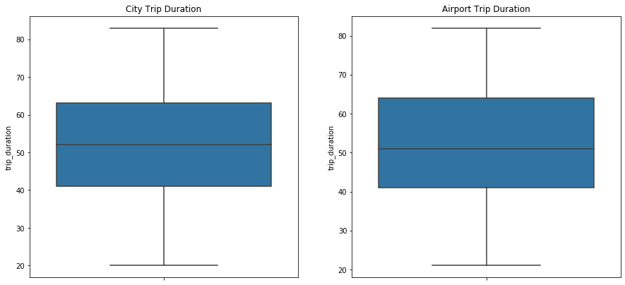

```python
plt.figure(figsize=(15,15))
plt.subplot(2,2,1)
#plt.xlim(-10,90)
sns.boxplot(y="trip_duration",data=df_ccom)
plt.title("City Trip Duration")

plt.subplot(2,2,2)
#plt.ylim(-10,4000)
sns.boxplot(y="trip_duration",data=df_acom)
plt.title("Airport Trip Duration")
plt.show()
```

#### From Box plots above we see that the median of the trips (City/Airport) (52,51) mins, only the mean is nearlly the same for both trips 52 mins, box plots says that 50% of theses completed trips below 52 mins for the City and below 51 mins for the Airport.

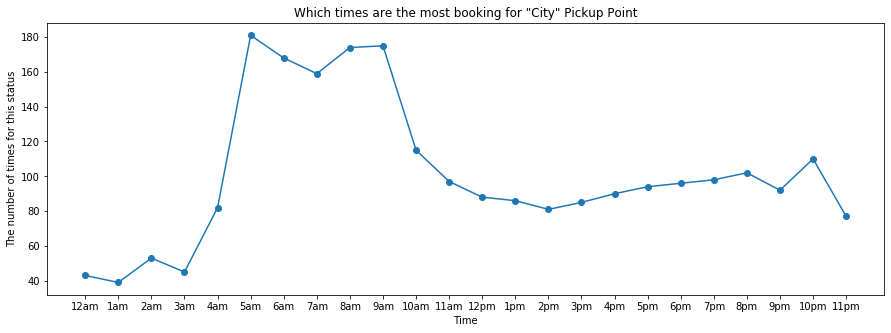

```python
# Which time is the most booking for "City" trips
df_ct = df[(df["Pickup point"] == "City") & (df['Status'] != "Cancelled")]
num = []
for i in range(0,24):
    x = df_ct[df_ct['Request timestamp'].dt.hour == i]
    b = x.Status.count()
    num.append(b)
plt.figure(figsize = (15,5))
axis_time = ["12am",'1am','2am','3am','4am','5am','6am','7am','8am','9am','10am','11am','12pm','1pm','2pm','3pm','4pm','5pm','6pm','7pm','8pm','9pm','10pm','11pm']
plt.plot(axis_time,num,marker ='o')
plt.title('Which times are the most booking for "City" Pickup Point')
plt.xlabel('Time')
plt.ylabel('The number of times for this status')
plt.show()
```

#### The Line plot above show that the most of "City" requests for clients are between 4 AM TO 11 AM, After 11 AM it nearly constant, NOTE THAT: these requests contains both Completed trips and requests which did not find a car available

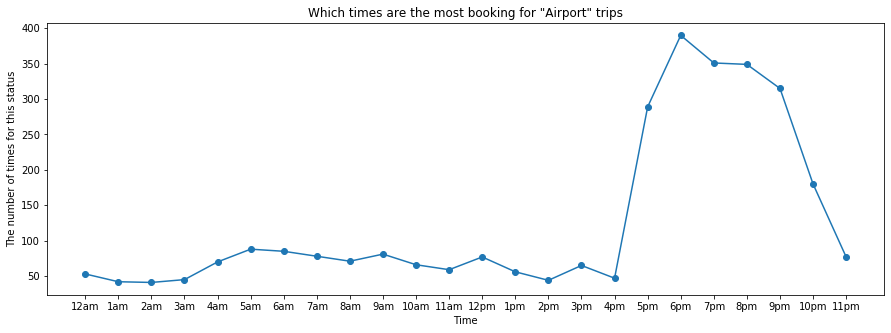

```python
# Which time is the most booking for "Airport" trips
df_at = df[(df["Pickup point"] == "Airport") & (df['Status'] != "Cancelled")]
num = []
for i in range(0,24):
    x = df_at[df_at['Request timestamp'].dt.hour == i]
    b = x.Status.count()
    num.append(b)
plt.figure(figsize = (15,5))
axis_time = ["12am",'1am','2am','3am','4am','5am','6am','7am','8am','9am','10am','11am','12pm','1pm','2pm','3pm','4pm','5pm','6pm','7pm','8pm','9pm','10pm','11pm']
plt.plot(axis_time,num,marker ='o')
plt.title('Which times are the most booking for "Airport" trips')
plt.xlabel('Time')
plt.ylabel('The number of times for this status')
plt.show()
```

#### The Line plot above show that the most of "Airport" requests for clients are between 5:00 pm TO 10:00 pm, After 10 pm it gonig decreasing , NOTE THAT: these requests contains both Completed trips and requests which did not find a car available.

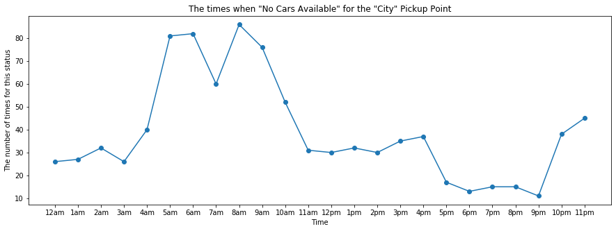

```python
#Number of "No Cars Available" over Time for City Pickup Point"
df_cno = df[(df["Pickup point"] == "City") & (df["Status"] == "No Cars Available")]
num = []
for i in range(0,24):
    x = df_cno[df_cno['Request timestamp'].dt.hour == i]
    b = x.Status.count()
    num.append(b)
plt.figure(figsize = (15,5))
axis_time = ["12am",'1am','2am','3am','4am','5am','6am','7am','8am','9am','10am','11am','12pm','1pm','2pm','3pm','4pm','5pm','6pm','7pm','8pm','9pm','10pm','11pm']
plt.plot(axis_time,num,marker ='o')
plt.title('The times when "No Cars Available" for the "City" Pickup Point')
plt.xlabel('Time')
plt.ylabel('The number of times for this status')
plt.show()
```

#### The Line plot above shows that the most of "City" requests which did not find cars available for clients are between 4:00 am to 11:00 am, After 11 pm, it nearly constant then it going a bit increase from 3pm to 4pm after that it went decrease but at 10 pm shows a trend again increasing in these requests to 11pm, NOTE THAT: these requests contains ONLY which did not find a car available.

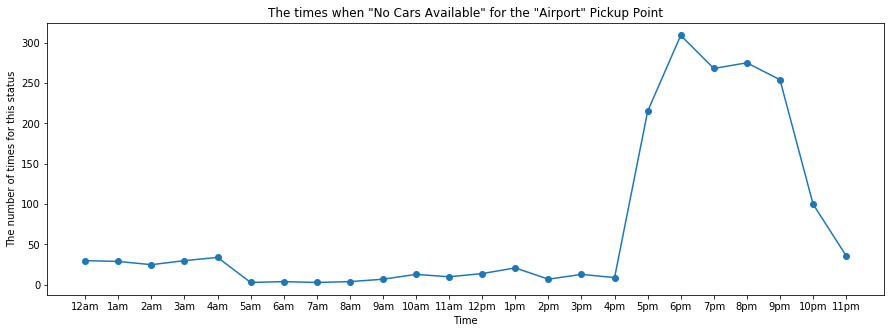

```python
#Plot
#Number of "No Cars Available" over Time for Airport Pickup Point"
df_ano = df[(df["Pickup point"] == "Airport") & (df["Status"] == "No Cars Available")]
num = []
for i in range(0,24):
    x = df_ano[df_ano['Request timestamp'].dt.hour == i]
    b = x.Status.count()
    num.append(b)
plt.figure(figsize = (15,5))
axis_time = ["12am",'1am','2am','3am','4am','5am','6am','7am','8am','9am','10am','11am','12pm','1pm','2pm','3pm','4pm','5pm','6pm','7pm','8pm','9pm','10pm','11pm']
plt.plot(axis_time,num,marker ='o')
plt.title('The times when "No Cars Available" for the "Airport" Pickup Point')
plt.xlabel('Time')
plt.ylabel('The number of times for this status')
plt.show()
```

#### The Line plot above show that the most of "Airport" requests which did not find cars available for clients are between 5:00 pm TO 10:00 pm, After 10 pm it gonig decreasing , NOTE THAT: these requests contains ONLY which did not find a car available.

# Conclusion

#### Note that:

#### - Company must direct most of the drivers for the Airport pickup point more than the drivers who would go for the peak times for the city pickup point due to the huge need for the Airport Pickup point than the need for the City as shown at the above plots.

#### - Also we could not find a reason for the cancelled trips due to the trips duration for both pickup point is normal so we could guess these requests as a data that could bias these analysis, thefore excluded from our data, as not to affect our decisions.